# Practical-3

Soumarya Basak

# Problem 1

## Data Input

```r
library(readr)
df<- read.csv("C:\\Users\\souma\\Dropbox\\Mstat_CU\\Sem 2\\Regression_analysis_1\\Data Sets\\cob-doglas.csv")
```

## Scatter Plot

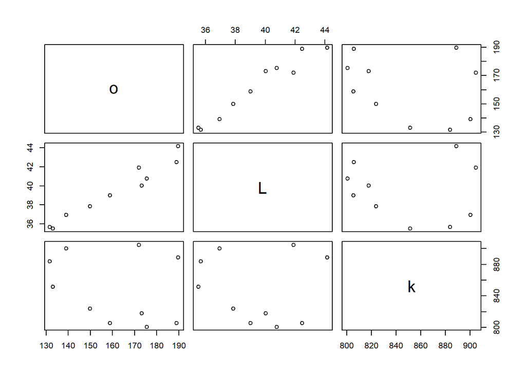

```r
plot(df[,-1])
```

We can see that `k` and `o` are not linearly related.

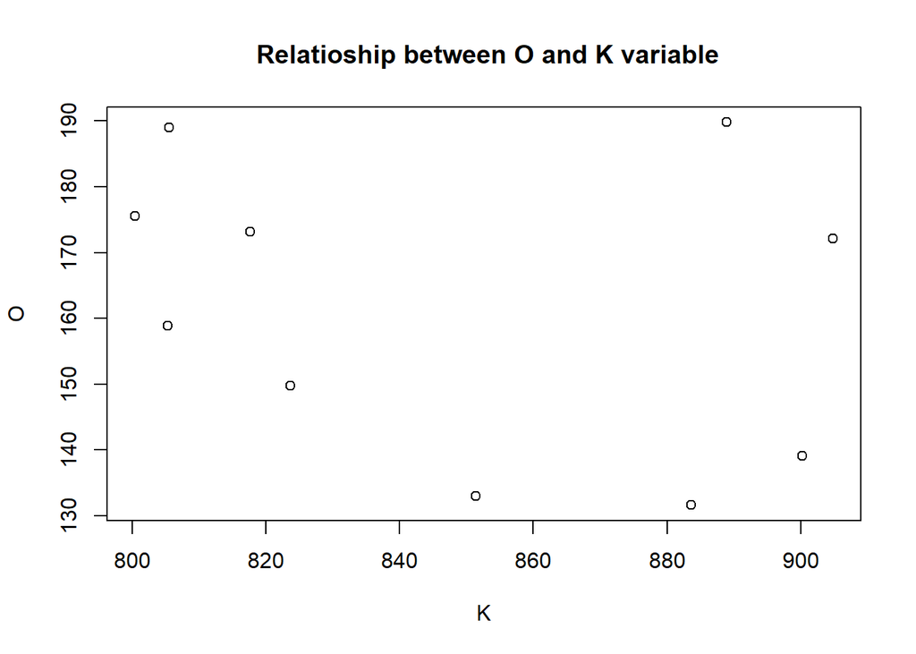

```r
plot(df$k, df$o, xlab="K", ylab = "O", main = " Relatioship between O and K variable")
```

Lets go for Cobb-Doglas Model

$$O_t=\alpha L_t^{\beta_1}k_{t}^{\beta_2}u_t$$
$$logO_t =\alpha^*+\beta_1logL_t+\beta_2logK_t+v_t$$
## Let’s Fit the model

```r
reg1<- lm(log(o)~log(L)+log(k),data = df)
summary(reg1)
```

```
##
## Call:
## lm(formula = log(o) ~ log(L) + log(k), data = df)
##
## Residuals:
##        Min         1Q     Median         3Q        Max
## -0.0186868 -0.0056866 -0.0004878  0.0031244  0.0296869
##
## Coefficients:
##             Estimate Std. Error t value Pr(>|t|)
## (Intercept)  2.22246    0.72109   3.082  0.01776 *
## log(L)       1.77558    0.06505  27.298 2.27e-08 ***
## log(k)      -0.54416    0.09704  -5.607  0.00081 ***
## ---
## Signif. codes:  0 '***' 0.001 '**' 0.01 '*' 0.05 '.' 0.1 ' ' 1
##
## Residual standard error: 0.01447 on 7 degrees of freedom
## Multiple R-squared:  0.9915, Adjusted R-squared:  0.9891
## F-statistic: 410.5 on 2 and 7 DF,  p-value: 5.557e-08
```

## Test for Durbin Watson Test

```r
library(car)
durbinWatsonTest(reg1)
```

```
##  lag Autocorrelation D-W Statistic p-value
##    1       0.2397808     0.8869685       0
##  Alternative hypothesis: rho != 0
```

So, under 95% level of significant we accept that there is Autocorrelation in the data.

The value of Durbin Watson Test statistics is , d= 0.8869685

## Remedial Measure

```r
library(orcutt)
cochrane.orcutt(reg1, convergence =5, max.iter=1000)
```

```
## Cochrane-orcutt estimation for first order autocorrelation
##
## Call:
## lm(formula = log(o) ~ log(L) + log(k), data = df)
##
##  number of interaction: 311
##  rho 0.996755
##
## Durbin-Watson statistic
## (original):    0.88697 , p-value: 7.837e-04
## (transformed): 2.34510 , p-value: 4.69e-01
##
##  coefficients:
## (Intercept)      log(L)      log(k)
##    1.894243    1.759270   -0.136710
```

## The Final Model

$$logO_t =1.894243 + (1.759270 \times logL_t)-(0.136710 \times logK_t)$$

# Problem 2

## Data

```r
library(readr)
df<- read.csv("C:\\Users\\souma\\Dropbox\\Mstat_CU\\Sem 2\\Regression_analysis_1\\Data Sets\\coal.csv")
head(df)
```

|  | ï..Year | Price.of.oil.cents. | Price.of.Bit.Coal |
| --- | --- | --- | --- |
| 1 | 1950 | 80.7 | 34.5 |
| 2 | 1951 | 76.4 | 32.9 |
| 3 | 1952 | 75.3 | 32.3 |
| 4 | 1953 | 78.5 | 32.0 |
| 5 | 1954 | 80.4 | 29.1 |
| 6 | 1955 | 78.6 | 28.4 |

```r
colnames(df)<- c("sl.no","x","y")
head(df)
```

|  | sl.no | x | y |
| --- | --- | --- | --- |
| 1 | 1950 | 80.7 | 34.5 |
| 2 | 1951 | 76.4 | 32.9 |
| 3 | 1952 | 75.3 | 32.3 |
| 4 | 1953 | 78.5 | 32.0 |
| 5 | 1954 | 80.4 | 29.1 |
| 6 | 1955 | 78.6 | 28.4 |

## Scatter Plot

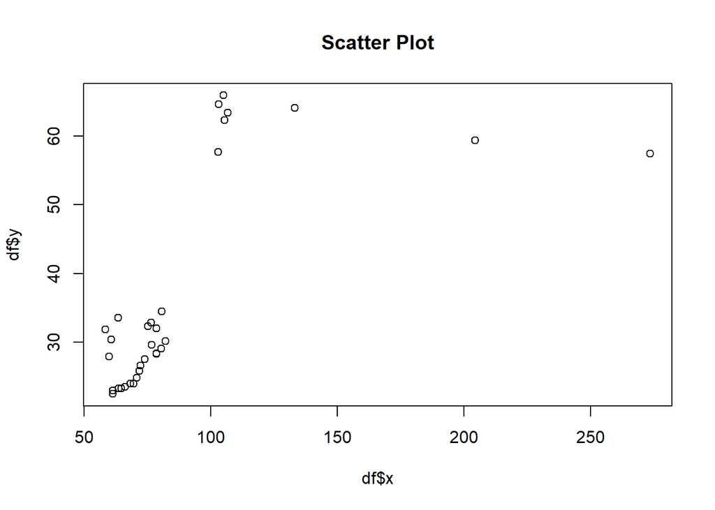

```r
plot(df$x,df$y,main = "Scatter Plot")
```

## Lets fit the model

```r
reg<- lm(y~x,data=df)
summary(reg)
```

```
##
## Call:
## lm(formula = y ~ x, data = df)
##
## Residuals:
##      Min       1Q   Median       3Q      Max
## -21.7402  -7.2003  -4.3925   0.9037  25.6624
##
## Coefficients:
##             Estimate Std. Error t value Pr(>|t|)
## (Intercept) 15.97256    4.70852   3.392  0.00196 **
## x            0.23088    0.04783   4.827  3.8e-05 ***
## ---
## Signif. codes:  0 '***' 0.001 '**' 0.01 '*' 0.05 '.' 0.1 ' ' 1
##
## Residual standard error: 11.72 on 30 degrees of freedom
## Multiple R-squared:  0.4372, Adjusted R-squared:  0.4184
## F-statistic:  23.3 on 1 and 30 DF,  p-value: 3.795e-05
```

## Check for influencial Observation

```r
influence.measures(reg)
```

```
## Influence measures of
##   lm(formula = y ~ x, data = df) :
##
##       dfb.1_     dfb.x    dffit cov.r   cook.d    hat inf
## 1  -0.000958  0.000284 -0.00162 1.106 1.36e-06 0.0322
## 2  -0.007519  0.003023 -0.01133 1.107 6.64e-05 0.0336
## 3  -0.011552  0.004908 -0.01696 1.107 1.49e-04 0.0341
## 4  -0.020748  0.007345 -0.03298 1.104 5.62e-04 0.0329
## 5  -0.050639  0.015428 -0.08500 1.090 3.71e-03 0.0323
## 6  -0.056624  0.019908 -0.09026 1.088 4.18e-03 0.0328
## 7  -0.042706  0.016985 -0.06465 1.098 2.15e-03 0.0336
## 8  -0.041430  0.010552 -0.07337 1.093 2.77e-03 0.0319
## 9  -0.057623  0.020259 -0.09186 1.088 4.33e-03 0.0328
## 10 -0.063283  0.028475 -0.09030 1.091 4.18e-03 0.0347
## 11 -0.072476  0.034802 -0.09993 1.089 5.12e-03 0.0356
```

[output cut: 21 more lines]

So, we get 4 influential measures— 26,29,31,32 th observation

Lets remove them and fit the data again

```r
df1<- df[-c(26,29,31,32),]

reg2<- lm(y~x, data=df1)
summary(reg2)
```

```
##
## Call:
## lm(formula = y ~ x, data = df1)
##
## Residuals:
##    Min     1Q Median     3Q    Max
## -6.244 -3.900 -1.848  1.802 11.135
##
## Coefficients:
##              Estimate Std. Error t value Pr(>|t|)
## (Intercept) -17.86915    5.16723  -3.458  0.00189 **
## x             0.66155    0.06598  10.027    2e-10 ***
## ---
## Signif. codes:  0 '***' 0.001 '**' 0.01 '*' 0.05 '.' 0.1 ' ' 1
##
## Residual standard error: 5.84 on 26 degrees of freedom
## Multiple R-squared:  0.7945, Adjusted R-squared:  0.7866
## F-statistic: 100.5 on 1 and 26 DF,  p-value: 2.005e-10
```

SO, after removing 4 observation, the model fits more well as adjusted $R^2$ increase.

```r
## Weighted least squares
##----------
## Since we are removing 4 observation and the data set is small
## so we are losing much of information, and the dfs are decreasing
## An alternative method for that is using  WLS
##----------

## Defining weights
wt<- 1/ cooks.distance(reg)
wt<- wt/ sum(wt)


wls_lm<- lm(y~x, data = df, weights = wt)
summary(wls_lm)
```

```
##
## Call:
## lm(formula = y ~ x, data = df, weights = wt)
##
## Weighted Residuals:
##      Min       1Q   Median       3Q      Max
## -0.09721 -0.09347 -0.08723  0.07004  0.09774
##
## Coefficients:
##             Estimate Std. Error t value Pr(>|t|)
## (Intercept) 16.65674    1.56581   10.64 1.06e-11 ***
## x            0.22073    0.01965   11.23 2.86e-12 ***
## ---
## Signif. codes:  0 '***' 0.001 '**' 0.01 '*' 0.05 '.' 0.1 ' ' 1
##
## Residual standard error: 0.08932 on 30 degrees of freedom
## Multiple R-squared:  0.8079, Adjusted R-squared:  0.8015
## F-statistic: 126.1 on 1 and 30 DF,  p-value: 2.864e-12
```

Now the weighted least square model gives a better model, lets check with mallow’s cp

```r
library(olsrr)
paste("For weighted LS:",ols_mallows_cp(wls_lm, reg) )
```

```
## [1] "For weighted LS: 2.055530179051"
```

```r
paste("Model after removing data: ", ols_mallows_cp(reg2, reg))
```

```
## [1] "Model after removing data:  -17.54783898327"
```

```r
# No of parameters p =2
# To choose best we have we minimize |Cp-p|

paste("For weighted LS the distance:",abs(ols_mallows_cp(wls_lm, reg)-2) )
```

```
## [1] "For weighted LS the distance: 0.0555301790510008"
```

```r
paste("Model after removing data the disatance: ", abs(ols_mallows_cp(reg2, reg)-2))
```

```
## [1] "Model after removing data the disatance:  19.54783898327"
```

So we will choose the weighted Ls model for further analysis

## Lets check for residuals

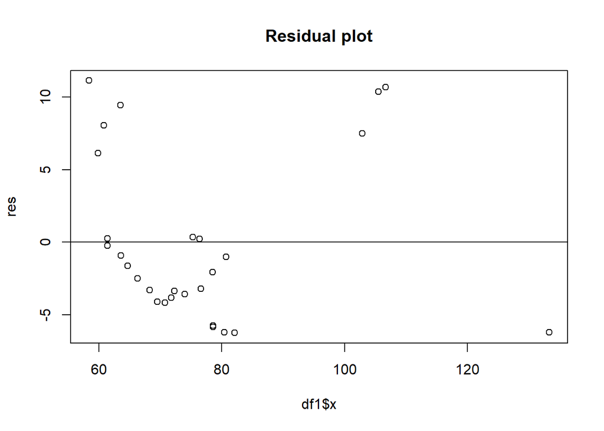

```r
res<- resid(reg2)

# residual plot
plot(df1$x,res,main = "Residual plot")
abline(h=0)
```

Its, unclear from the residual plot that is there heterosecdasticity present or not.

So, lets test it, ##### GQ Test

```r
library(lmtest)
gqtest(reg2, fraction = 8 ,order.by = ~x,data = df1)
```

```
##
##  Goldfeld-Quandt test
##
## data:  reg2
## GQ = 3.1441, df1 = 8, df2 = 8, p-value = 0.06281
## alternative hypothesis: variance increases from segment 1 to 2
```

The p-value is =0.06281 So, we fail to reject the null, SO the data is homoscedastic

## Check for Autocorrelation

### Durbin Watson Test

```r
library(car)
durbinWatsonTest(reg2)
```

```
##  lag Autocorrelation D-W Statistic p-value
##    1       0.7580202     0.4392214       0
##  Alternative hypothesis: rho != 0
```

Since the p value is less than 0.05

SO, we reject the null that autocorrelation is absent

So, there is Autocorrelation in the data

## Remedial Measure

```r
library(orcutt)
cochrane.orcutt(reg2, convergence = 8, max.iter = 1000)
```

```
## Cochrane-orcutt estimation for first order autocorrelation
##
## Call:
## lm(formula = y ~ x, data = df1)
##
##  number of interaction: 16
##  rho 0.925707
##
## Durbin-Watson statistic
## (original):    0.43922 , p-value: 4.543e-08
## (transformed): 1.13436 , p-value: 6.381e-03
##
##  coefficients:
## (Intercept)           x
##    3.235024    0.428367
```

## The Final MOdel

$$y=3.235024 + 0.428367 \times x$$

where $y=$ Price of Bit.coal, and $x=$ Price of oil

### Scatter Plot

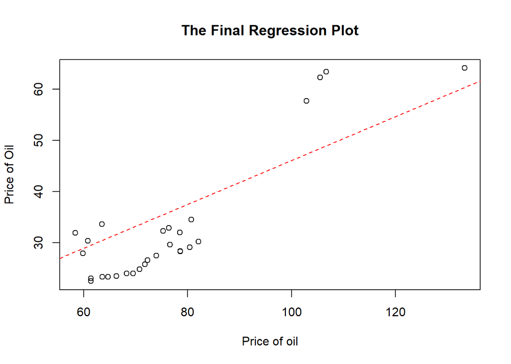

```r
plot(df1$x,df1$y,main = "The Final Regression Plot",xlab="Price of oil",ylab = "Price of Oil")
abline(3.235024,0.428367,col='red',lty=2)
```

But as here is only one regressor w can’t find the auto correlation among the regressor, and the GQ test also significes the absence of heteroscedasticity so we will stick to the model after removing the influential observation and the model is

$$y=-17.86915 + 0.66155\times X$$

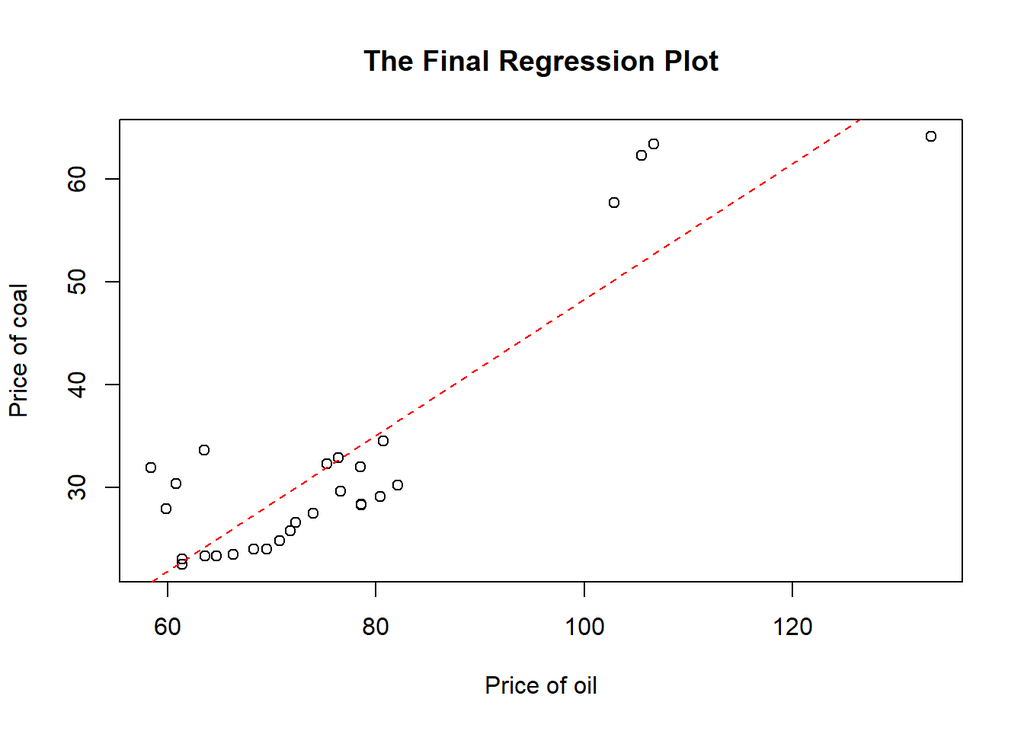

```r
plot(df1$x,df1$y,main = "The Final Regression Plot",xlab="Price of oil",ylab = "Price of coal")
abline(-17.86915,0.66155  ,col='red',lty=2)
```